# The General Linear Model - ANOVA Part 1

Andrew Stewart, Email: drandrewjstewart@gmail.com, Twitter: @ajstewart_lang

# Overview

In this workshop we will examine how to conduct Analysis of Variance (ANOVA) in R. We will begin by exploring why we tend to use ANOVA (rather than multiple *t*-tests), before moving on to some examples of ANOVA for between participants and repeated measures designs.

[video not shown]

## Slides

If you have a Google account, you can also view and download the slides in a range of formats by clicking on the image below. If you don’t have a Google account, you can download the slides in .pdf format by clicking here.

[figure not shown]

In this second video, I will show you how to build a between participants ANOVA model in R using the `afex::` package.

[video not shown]

## Slides

If you have a Google account, you can also view and download the slides in a range of formats by clicking on the image below. If you don’t have a Google account, you can download the slides in .pdf format by clicking here.

[figure not shown]

After you’ve watched both of the videos above, it’s your turn to build your first ANOVA in R for a between participants design. This is the same data (from the same study) that I covered in the second of the two videos above. Follow the instructions below to build that model.

# Between Participants ANOVA

## Loading our Packages

First of all, we need to load the three packages we will be using - they are `tidyverse`, `afex`, and `emmeans`. The `afex::` package is the one we use for conducting factorial ANOVA. We use the `emmeans` package for running follow-up tests on the ANOVA model that we will be building.

```r
library(tidyverse)
library(afex)
library(emmeans)
```

## Reading in our Data

We have 45 participants in a between participants design where we are interested in the effect of beverage consumed on ability on a motor task. Our experimental factor (beverage type) has 3 levels. These are Water vs. Single Espresso vs. Double Espresso, and Ability is our DV measured on a continuous scale. Let’s read in our data.

```r
my_data <- read_csv("https://raw.githubusercontent.com/ajstewartlang/11_glm_anova_pt1/master/data/cond.csv")
head(my_data)
```

```
## # A tibble: 6 x 3
##   Participant Condition Ability
##         <dbl> <chr>       <dbl>
## 1           1 Water        4.82
## 2           2 Water        5.41
## 3           3 Water        5.73
## 4           4 Water        4.36
## 5           5 Water        5.47
## 6           6 Water        5.50
```

We see that we have three variables, but our experimental variable `Condition` is not coded as a factor. Let’s fix that…

```r
my_data_tidied <- my_data %>%
  mutate(Condition = factor(Condition))
head(my_data_tidied)
```

```
## # A tibble: 6 x 3
##   Participant Condition Ability
##         <dbl> <fct>       <dbl>
## 1           1 Water        4.82
## 2           2 Water        5.41
## 3           3 Water        5.73
## 4           4 Water        4.36
## 5           5 Water        5.47
## 6           6 Water        5.50
```

## Summarising our Data

Let’s work our some summary statistics and build a data visualisation next.

```r
my_data_tidied %>%
  group_by(Condition) %>%
  summarise(mean = mean(Ability), sd = sd(Ability))
```

```
## # A tibble: 3 x 3
##   Condition         mean    sd
##   <fct>            <dbl> <dbl>
## 1 Double Espresso   8.89 0.467
## 2 Single Espresson  6.99 0.419
## 3 Water             5.17 0.362
```

## Visualising our Data

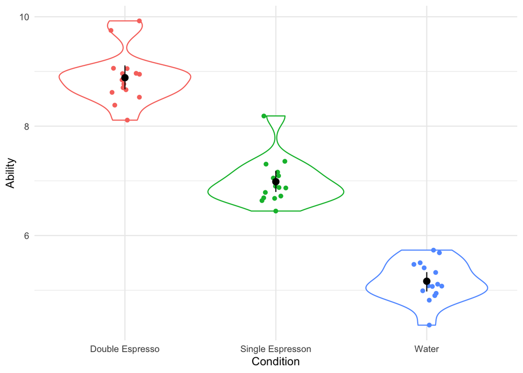

```r
set.seed(1234)
my_data_tidied %>%
  ggplot(aes(x = Condition, y = Ability, colour = Condition)) +
  geom_violin() +
  geom_jitter(width = .1) +
  guides(colour = FALSE) +
  stat_summary(fun.data = "mean_cl_boot", colour = "black") +
  theme(text = element_text(size = 13)) +
  theme_minimal()
```

We have built a visualisation where we have plotted the raw data points using the `geom_jitter()` function, and the shape of the distribution for each condition using the `geom_violin()` function. We have also added some summary data in the form of the Mean and Confidence Intervals around the Mean using the `stat_summary()` function.

## Building our ANOVA Model

Let’s now build our model using the `aov_4()` function in the afex:: package. The syntax for ANOVA models in `aov_4()` is: `aov_4(DV ~ IV + (1 | Participant), data = my_data_tidied)`. The `~` symbol means predicted by, the `(1 | Participant)` term corresponds to our random effect - we obviously can’t test all the participants in the world so have taken just a random sample from this population. Finally, we need to specify what dataset we are using by making that clear in the `data = my_data_tidied` bit of the model. We are going to map the output of the `aov()` function onto a variable I’m calling `model`. This means that the ANOVA results will be stored in this variable and will allow us to access them later.

```r
model <- aov_4(Ability ~ Condition + (1 | Participant), data = my_data_tidied)
```

```
## Contrasts set to contr.sum for the following variables: Condition
```

To get the output of the ANOVA, we can use the `summary()` function with our newly created `model`.

## Interpreting the Model Output

```r
summary(model)
```

```
## Anova Table (Type 3 tests)
##
## Response: Ability
##           num Df den Df     MSE      F     ges    Pr(>F)
## Condition      2     42 0.17484 297.05 0.93397 < 2.2e-16 ***
## ---
## Signif. codes:  0 '***' 0.001 '**' 0.01 '*' 0.05 '.' 0.1 ' ' 1
```

The effect size (ges) is generalised eta squared and for designs with more than one factor it can be a useful indicator of how much variance in the dependent variable can be explained by each factor (plus any interactions between factors).

So, we there is an effect in our model - the F-value is pretty big and the *p*-value pretty small) but we can’t know what’s driving the difference yet. We need to run some pairwise comparisons using the `emmeans()` function to tell us what mean(s) differ(s) from what other mean(s).

```r
emmeans(model, pairwise ~ Condition)
```

```
## $emmeans
##  Condition        emmean    SE df lower.CL upper.CL
##  Double Espresso    8.89 0.108 42     8.67     9.10
##  Single Espresson   6.99 0.108 42     6.77     7.20
##  Water              5.17 0.108 42     4.95     5.38
##
## Confidence level used: 0.95
##
## $contrasts
##  contrast                           estimate    SE df t.ratio p.value
##  Double Espresso - Single Espresson     1.90 0.153 42 12.453  <.0001
##  Double Espresso - Water                3.72 0.153 42 24.372  <.0001
##  Single Espresson - Water               1.82 0.153 42 11.920  <.0001
##
## P value adjustment: tukey method for comparing a family of 3 estimates
```

Note that the default adjustment for multiple comparisons is Tukey’s. We can change that by adding an extra parameter to our model such as `adjust = "bonferonni")`. In this case, it doesn’t make any difference to our comparisons.

```r
emmeans(model, pairwise ~ Condition, adjust = "bonferroni")
```

```
## $emmeans
##  Condition        emmean    SE df lower.CL upper.CL
##  Double Espresso    8.89 0.108 42     8.62     9.16
##  Single Espresson   6.99 0.108 42     6.72     7.25
##  Water              5.17 0.108 42     4.90     5.43
##
## Confidence level used: 0.95
## Conf-level adjustment: bonferroni method for 3 estimates
##
## $contrasts
##  contrast                           estimate    SE df t.ratio p.value
##  Double Espresso - Single Espresson     1.90 0.153 42 12.453  <.0001
##  Double Espresso - Water                3.72 0.153 42 24.372  <.0001
##  Single Espresson - Water               1.82 0.153 42 11.920  <.0001
##
## P value adjustment: bonferroni method for 3 tests
```

We found a significant effect of Beverage type (F (2,42) = 297.05, *p* < .001, generalised η2 = .93). Tukey comparisons revealed that the Water group performed significantly worse than the Single Espresso Group (*p* < .001), that the Water group performed significantly worse than the Double Espresso Group (*p* < .001), and that the Single Espresso Group performed significantly worse than the Double Espresso Group (*p* < .001).

In other words, drinking some coffee improves motor performance relative to drinking water, and drinking a lot of coffee improves motor performance even more.

# Repeated Measures ANOVA

[video 3]

Now it’s your chance to work with the data I examined in the video above. Let’s imagine we have an experiment where we asked 32 participants to learn how to pronounce words of differing levels of complexity - Very Easy, Easy, Hard, and Very Hard. They were presented with these words in an initial exposure phase. After a 30 minute break we tested participants by asking them to say the words out loud when they appeared on a computer screen. We recorded their times in seconds. We want to know whether there is a difference in their response times for each level of word complexity.

## Reading in our Data

First we read in the data.

```r
rm_data <- read_csv("https://raw.githubusercontent.com/ajstewartlang/11_glm_anova_pt1/master/data/rm_data.csv")
head(rm_data)
```

```
## # A tibble: 6 x 3
##   Participant Condition    RT
##         <dbl> <chr>     <dbl>
## 1           1 Very Easy  1.25
## 2           2 Very Easy  1.16
## 3           3 Very Easy  1.12
## 4           4 Very Easy  1.33
## 5           5 Very Easy  1.16
## 6           6 Very Easy  1.15
```

We can see from the `head()` function that Condition isn’t yet coded as a factor. Let’s fix that.

```r
rm_data_tidied <- rm_data %>%
  mutate(Condition = factor(Condition))
head(rm_data_tidied)
```

```
## # A tibble: 6 x 3
##   Participant Condition    RT
##         <dbl> <fct>     <dbl>
## 1           1 Very Easy  1.25
## 2           2 Very Easy  1.16
## 3           3 Very Easy  1.12
## 4           4 Very Easy  1.33
## 5           5 Very Easy  1.16
## 6           6 Very Easy  1.15
```

## Summarising our Data

Let’s generate the Mean and Standard Deviation for each of our four conditions.

```r
rm_data_tidied %>%
  group_by(Condition) %>%
  summarise(mean = mean(RT), sd = sd (RT))
```

```
## # A tibble: 4 x 3
##   Condition  mean     sd
##   <fct>     <dbl>  <dbl>
## 1 Easy       1.23 0.0610
## 2 Hard       1.39 0.118
## 3 Very Easy  1.20 0.0511
## 4 Very Hard  1.87 0.187
```

## Visualising our Data

And visualise the data - note here that I am using the `fct_reorder()` function to reorder the levels of our factor based on the RT. This can be useful to make our viusalisations more easily interpretable.

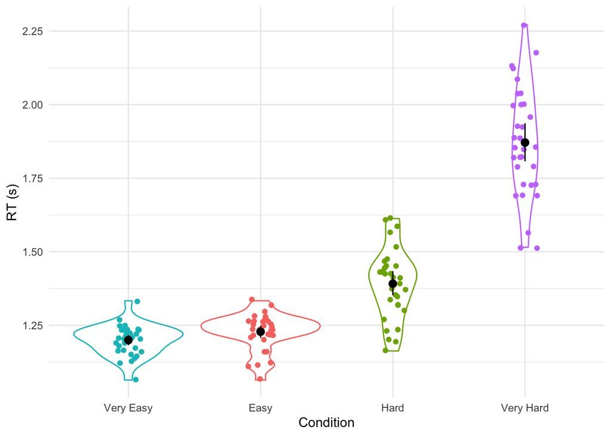

```r
rm_data_tidied %>%
  ggplot(aes(x = fct_reorder(Condition, RT), y = RT, colour = Condition)) +
  geom_violin() +
  geom_jitter(width = .1) +
  guides(colour = FALSE) +
  stat_summary(fun.data = "mean_cl_boot", colour = "black") +
  theme(text = element_text(size = 13)) +
  theme_minimal() +
  labs(x = "Condition", y = "RT (s)")
```

## Building our ANOVA Model

We build our ANOVA model in a similar way as we did previously. Except in this case our random effect we define as `(1 + Condition | Participant)`. I order to capture the fact that our `Condition` is a repeated measures factor, we add it to the random effect term like this.

```r
rm_model <- aov_4(RT ~ Condition + (1 + Condition | Participant), data = rm_data_tidied)
```

## Interpreting the Model Output

We extract the summary of our model in the same way we did for the between participants ANOVA.

```r
summary(rm_model)
```

```
##
## Univariate Type III Repeated-Measures ANOVA Assuming Sphericity
##
##             Sum Sq num Df Error SS den Df  F value    Pr(>F)
## (Intercept) 259.07      1  0.50313     31 15962.33 < 2.2e-16 ***
## Condition     9.27      3  1.20624     93   238.23 < 2.2e-16 ***
## ---
## Signif. codes:  0 '***' 0.001 '**' 0.01 '*' 0.05 '.' 0.1 ' ' 1
##
##
## Mauchly Tests for Sphericity
##
##           Test statistic    p-value
## Condition        0.38404 3.0211e-05
##
##
## Greenhouse-Geisser and Huynh-Feldt Corrections
##  for Departure from Sphericity
##
##            GG eps Pr(>F[GG])
## Condition 0.65596  < 2.2e-16 ***
## ---
## Signif. codes:  0 '***' 0.001 '**' 0.01 '*' 0.05 '.' 0.1 ' ' 1
##
##              HF eps   Pr(>F[HF])
## Condition 0.7000534 3.359493e-31
```

With this option, we didn’t get the effect size measure in our measure. We can generate that though by asking for our model to be presented in anova format using the `anova()` function.

```r
anova(rm_model)
```

```
## Anova Table (Type 3 tests)
##
## Response: RT
##           num Df den Df      MSE      F     ges    Pr(>F)
## Condition 1.9679 61.004 0.019773 238.23 0.84431 < 2.2e-16 ***
## ---
## Signif. codes:  0 '***' 0.001 '**' 0.01 '*' 0.05 '.' 0.1 ' ' 1
```

The effect size is measured by ges and is the recommended effect size measure for repeated measures designs (Bakeman, 2005). Note the dfs in this output are always corrected as if there is a violation of sphericity (violated when the variances of the differences between all possible pairs of within-subject conditions (i.e., levels of the independent variable) are **not** equal) - to be conservative (and to avoid Type I errors) we might be better off to always choose these corrected dfs.

From this, we can see we have effect of Condition. But we don’t know where the differences lie between the different levels of our factor. So we use the `emmeans()` function to find that out. Here we will be using the Bonferroni correction for multiple comparisons.

```r
emmeans(rm_model, pairwise ~ Condition, adjust = "Bonferroni")
```

```
## $emmeans
##  Condition emmean     SE  df lower.CL upper.CL
##  Easy        1.23 0.0208 123     1.18     1.28
##  Hard        1.39 0.0208 123     1.34     1.44
##  Very.Easy   1.20 0.0208 123     1.15     1.25
##  Very.Hard   1.87 0.0208 123     1.82     1.92
##
## Warning: EMMs are biased unless design is perfectly balanced
## Confidence level used: 0.95
## Conf-level adjustment: bonferroni method for 4 estimates
##
## $contrasts
##  contrast              estimate     SE df t.ratio p.value
##  Easy - Hard            -0.1633 0.0285 93  -5.735 <.0001
##  Easy - Very.Easy        0.0285 0.0285 93   1.000 1.0000
##  Easy - Very.Hard       -0.6430 0.0285 93 -22.584 <.0001
##  Hard - Very.Easy        0.1917 0.0285 93   6.734 <.0001
##  Hard - Very.Hard       -0.4797 0.0285 93 -16.849 <.0001
##  Very.Easy - Very.Hard  -0.6715 0.0285 93 -23.584 <.0001
##
## P value adjustment: bonferroni method for 6 tests
```

From the above we can see that all conditions differ from all other conditions, *apart* from the Easy vs. Very Easy comparison which is not significant.

# Factorial ANOVA

[video 4]

## Reading in our Data

```r
factorial_data <- read_csv("https://raw.githubusercontent.com/ajstewartlang/11_glm_anova_pt1/master/data/factorial_data.csv")
head(factorial_data)
```

```
## # A tibble: 6 x 5
##   Subject  Item    RT Sentence Context
##     <dbl> <dbl> <dbl> <chr>    <chr>
## 1       1     3  1270 Positive Negative
## 2       1     7   739 Positive Negative
## 3       1    11   982 Positive Negative
## 4       1    15  1291 Positive Negative
## 5       1    19  1734 Positive Negative
## 6       1    23  1757 Positive Negative
```

Again we see that our two experimental factors are not coded as factors so let’s fix that.

```r
factorial_data_tidied <- factorial_data %>%
  mutate(Sentence = factor(Sentence), Context = factor(Context))
```

## Summarising our Data

Ler’s generate some summary statistics - note, we sepcificy our two grouping variables in the `group_by()` function call.

```r
factorial_data_tidied %>%
  group_by(Context, Sentence) %>%
  summarise(mean_rt = mean(RT), sd_rt = sd(RT))
```

```
## # A tibble: 4 x 4
## # Groups:   Context [2]
##   Context  Sentence mean_rt sd_rt
##   <fct>    <fct>      <dbl> <dbl>
## 1 Negative Negative   1474.  729.
## 2 Negative Positive     NA    NA
## 3 Positive Negative     NA    NA
## 4 Positive Positive   1579.  841.
```

We have `NA` for two conditions suggesting we have missing data somewhere in our dataset. We’re going to use a new package now, called `visdat`. It allows us to visualise our dataset using the `vis_dat()` function and to visualise missing data using the `vis_miss()` function.

```r
library(visdat)
```

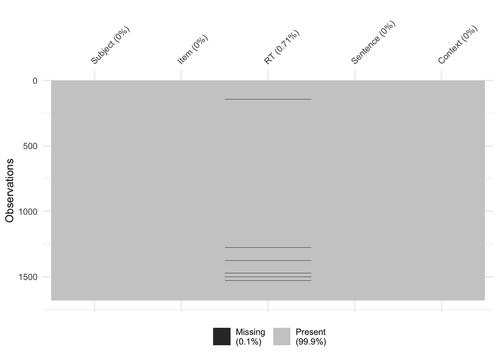

```r
vis_miss(factorial_data_tidied)
```

We can see in the above visualisation that we do indeed have some missing data. We need to tell R what we want it to do with that. We can use the `na.rm = TRUE` parameter to tell it we want missing data to be ignored.

```r
factorial_data_tidied %>%
  group_by(Context, Sentence) %>%
  summarise(mean_rt = mean(RT, na.rm = TRUE), sd_rt = sd(RT, na.rm = TRUE))
```

```
## # A tibble: 4 x 4
## # Groups:   Context [2]
##   Context  Sentence mean_rt sd_rt
##   <fct>    <fct>      <dbl> <dbl>
## 1 Negative Negative   1474.  729.
## 2 Negative Positive   1595.  887.
## 3 Positive Negative   1633.  877.
## 4 Positive Positive   1579.  841.
```

Now we have the summary statistics that we expect.

## Visualising our Data

We can use a modification of the `ggplot()` code we’ve used above to generate our visualisation. Note, I am filtering our the missing data using the `filter()` function before we start our plot. I am also specifying that we’re wanting to plot a combination of our two factors in the `aes()` definition using `Context:Sentence`. There are further things we could modify to improve the look of this graph. Can you figure out ways in which the labelling of the two factors could be clearer?

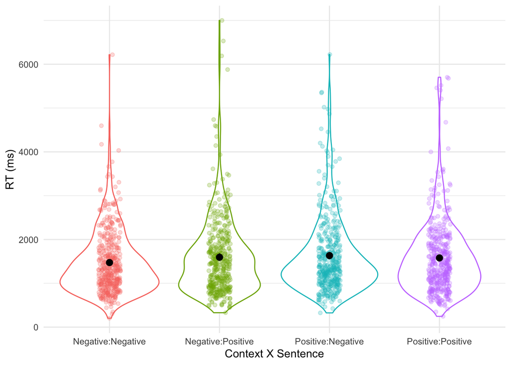

```r
factorial_data_tidied %>%
  filter(!is.na(RT)) %>%
  ggplot(aes(x = Context:Sentence, y = RT, colour = Context:Sentence)) +
  geom_violin() +
  geom_jitter(width = .1, alpha = .25) +
  guides(colour = FALSE) +
  stat_summary(fun.data = "mean_cl_boot", colour = "black") +
  theme(text = element_text(size = 13)) +
  theme_minimal() +
  labs(x = "Context X Sentence", y = "RT (ms)")
```

## Building our ANOVA Model

We have our data in long format where every row is one observation. We haven’t done any data aggregation. The `aov_4()` function will do this for us as ANOVA models need to be built over means (not raw data). As the data haven’t been aggregeated, we could actually build two ANOVA models with the data in the current format. We could build one ANOVA where we treat Subjects as a random effect (also known as F1 ANOVA), and another where we treat Items as a random factor (also known as F2 ANOVA). In language research, it’s commonplace to conduct both types of analysis. The by-items (F2) analysis allows us to ensure any effects we might find aren’t limited to just a subset of experimental items.

First we’ll look at how to run a by-subjects ANOVA for our factorial design using `aov_4()`. The syntax is very similar to what we ran previously, although this time you’ll see we have a new term `Context * Sentence`. This term corresponds to two main effects, plus the interaction between them. It’s shorthand for `Context + Sentence + Context:Sentence`. We also specify this in the random effect By setting `na.rm` to be TRUE, we are telling the analysis to ignore individual trials where there might be missing data - effectively this calculates the condition means over the data that is present (and ignores trials where it is missing).

```r
model_subjects <- aov_4(RT ~ Context * Sentence + (1 + Context * Sentence | Subject), data = factorial_data_tidied, na.rm = TRUE)
```

We can generate the output using the `anova()` function as we did earlier.

```r
anova(model_subjects)
```

```
## Anova Table (Type 3 tests)
##
## Response: RT
##                  num Df den Df    MSE      F       ges  Pr(>F)
## Context               1     59  90195 3.1767 0.0060231 0.07984 .
## Sentence              1     59 124547 0.6283 0.0016524 0.43114
## Context:Sentence      1     59  93889 4.5967 0.0090449 0.03616 *
## ---
## Signif. codes:  0 '***' 0.001 '**' 0.01 '*' 0.05 '.' 0.1 ' ' 1
```

If we want to generate the F2 ANOVA (by items), we simply change the random effect such that it is calculed by Items rather than by Subjects.

```r
model_items <- aov_4(RT ~ Context * Sentence + (1 + Context * Sentence | Item), data = factorial_data_tidied, na.rm = TRUE)
anova(model_items)
```

```
## Anova Table (Type 3 tests)
##
## Response: RT
##                  num Df den Df    MSE      F       ges  Pr(>F)
## Context               1     27  39844 4.0013 0.0080150 0.05561 .
## Sentence              1     27 203164 0.1221 0.0012553 0.72951
## Context:Sentence      1     27  40168 5.7687 0.0116070 0.02346 *
## ---
## Signif. codes:  0 '***' 0.001 '**' 0.01 '*' 0.05 '.' 0.1 ' ' 1
```

You can see that the F1 and F2 analysis both produce similar results.

Let’s now interpret our ANOVA where we had Subjects as our random effect. We will the error correction adjustment to equal `none` as only some of the comparisons actually make theoretical sense - these are the ones where we’re comparing like with like - Sentences of the same type (Positive *or* Negative) preceded by one version of our Context factor vs. the other.

```r
emmeans(model_subjects, pairwise ~ Context * Sentence, adjust = "none")
```

```
## $emmeans
##  Context  Sentence emmean   SE  df lower.CL upper.CL
##  Negative Negative   1474 57.8 138     1360     1588
##  Positive Negative   1628 57.8 138     1514     1742
##  Negative Positive   1595 57.8 138     1481     1709
##  Positive Positive   1579 57.8 138     1465     1693
##
## Warning: EMMs are biased unless design is perfectly balanced
## Confidence level used: 0.95
##
## $contrasts
##  contrast                              estimate   SE  df t.ratio p.value
##  Negative Negative - Positive Negative   -153.9 55.4 118 -2.779  0.0064
##  Negative Negative - Negative Positive   -120.9 60.3 116 -2.004  0.0474
##  Negative Negative - Positive Positive   -105.2 59.8 115 -1.759  0.0813
##  Positive Negative - Negative Positive     33.0 59.8 115  0.551  0.5824
##  Positive Negative - Positive Positive     48.7 60.3 116  0.807  0.4213
##  Negative Positive - Positive Positive     15.7 55.4 118  0.284  0.7772
```

The key comparisons are the `Negative Negative - Positive Negative` and the `Negative Positive - Positive Positive` ones. In the first case, we are comparing reaction times to Negative Sentences preceded by Negative vs. Positive Contexts, while in the second we are comparing reaction times to Positive Sentences preceded by Negative vs. Positive Contexts. We can manually correct for multiple comparisons (which in this case is 2) by multiplying the corresponding *p*-values by 2 (and putting a limit of 1 on the maximum *p*-value possible). In this case, the first key comparison is sigficant (*p* = .012) while the second is not. We might write up the results like:

We conducted a 2 (Context: Positive vs. Negative) x 2 (Sentence: Positive vs. Negative) repeated measures ANOVA to investigate the influence of Context valence on reaction times to Sentences of Positive or Negative valence. The ANOVA revealed no effect of Sentence (F < 1), no effect of Context (F(1, 59) = 3.18, *p* = .080, ηG2 = .006), but an interaction between Sentence and Context (F(1, 59) = 4.60, *p* = .036, ηG2 = .009).

The interaction was interpreted by conducting Bonferroni-corrected pairwise companions. These comparisons revealed that the interaction was driven by Negative Sentences being processed faster in Negative vs. Positive Contexts (1,474 ms. vs. 1,628 ms., t(118) = 2.78, *p* = .012) while Positive Sentences were read at similar speeds in Negative vs. Positive Contexts (1,595 ms. vs. 1,579 ms., t(118) = .284, *p* = 1).

# Your Challenge

I would now like you to work on the following three questions on your own.

## Question 1

Our first data file is called ANOVA_lab1_data1.csv and can be found here:

https://raw.githubusercontent.com/ajstewartlang/11_glm_anova_pt1/master/data/ANOVA_data1.csv

24 participants responded to a word that was either common (i.e., high lexical frequency) or rare (i.e., low lexical frequency). This is our IV and is coded as ‘high’ vs. lLow’. Our DV is reaction time and is coded as ‘RT’. Subject number is coded as ‘Subject’. We want to know whether there is a difference between conditions (and if so, where that difference lies). Visualise the data, generate descrtiptives, and run the appropriate ANOVA to determine whether our independent variable (Condition) has an influence on our dependent variable (RT).

## Question 2

Our second data file is called ANOVA_lab1_data2.csv and can be found here:

https://raw.githubusercontent.com/ajstewartlang/11_glm_anova_pt1/master/data/ANOVA_data2.csv

These data are also from a reaction time experiment but with a slightly more complex design. 48 participants responded to a word that differed in how frequent it was. This factor is between participants and we have four levels coded as ‘very low’, ‘low’, ‘high’, and ‘very high’. Our DV is reaction time and is coded as ‘RT’. Subject number is coded as ‘Subject’. We want to know if there is a difference between our conditions (and if so, where that difference lies).

## Question 3

Our third data file is called ANOVA_lab1_data3.csv and can be found here:

https://raw.githubusercontent.com/ajstewartlang/11_glm_anova_pt1/master/data/ANOVA_data3.csv

These data are from a 2 x 2 repeated measures reaction time experiment. We were interested in how quickly participants could respond to images that were Large vs. Small and in Colour vs. Black & White. We expect that Large Colour images will be responded to more quickly than Small B & W images. We’re not sure about Small Colour images and Large B & W images. We measured the response times of 24 participants responding to an image in each of these four conditions. We want to determine if there is a difference between our conditions (and if so, where that difference lies).

## Improve this Workshop

If you spot any issues/errors in this workshop, you can raise an issue or create a pull request for [this repo](https://github.com/ajstewartlang/11_glm_anova_pt1).